# R exam, Spring 2020

### Question 1: Structure (10 points)

**a. There are several seemingly repetitive sets of columns: `last_name / full_name`; `district / district_fip`; and `age_at_session_start / dob`. Why might it be useful to have two variables that contain the such similar information?** (5 points)

(YOUR ANSWER HERE)

**b. What is one interesting question about the House of Representatives that can’t be answered by this dataset alone.** (5 points)

(YOUR ANSWER HERE)

### Question 2: Inspection (10 points)

**a. Describe what the following code chunk accomplishes.** (5 points) (When you do these types of questions, describe it in plain English to someone who knows nothing about R or about data analysis.)

(YOUR ANSWER HERE)

**b. Why is it be useful to examine a few rows that contain famous examples or others that you are already know in real life?** (5 points)

(YOUR ANSWER HERE)

```r
house %>%
  filter ( last_name %in% c("Ocasio-Cortez", "Pelosi") )  %>%
  glimpse()
```

```
## Rows: 2
## Columns: 15
## $ id                      <chr> "O000172", "P000197"
## $ last_name               <chr> "Ocasio-Cortez", "Pelosi"
## $ full_name               <chr> "Ocasio-Cortez, Alexandria ", "Pelosi, Nancy "
## $ age_at_session_start    <int> 29, 78
## $ state                   <chr> "NY", "CA"
## $ district                <chr> "14", "12"
## $ district_fip            <chr> "3614", "0612"
## $ gender                  <chr> "F", "F"
## $ party                   <chr> "D", "D"
## $ seniority               <int> 2, 32
## $ total_votes             <int> 919, 919
## $ total_present           <int> 1, 0
## $ missed_votes            <int> 6, 837
## $ votes_against_party_pct <dbl> 5.16, 0.00
## $ dob                     <date> 1989-10-13, 1940-03-26
```

### Question 3: Extremes (10 points)

All of these questions refer to the three code chunks below.

**a. In your own words, what questions are being answered in the following code chunks?**

(Note: Justin Amash left the Republican party in July 2019, and became an Independent member.)

(YOUR ANSWER HERE)

**b. Why might a reporter ask these questions?**

(YOUR ANSWER HERE)

**c. List *two* other variables that might yield some information simply by arranging them to look at extreme highs and lows?**

(YOUR ANSWER HERE)

```r
house %>%
  arrange(votes_against_party_pct) %>%
  select (last_name, age=age_at_session_start, state, gender, party, votes_against_party_pct) %>%
  tail( 10)
```

|  | last_name | age | state | gender | party | votes_against_party_pct |
| --- | --- | --- | --- | --- | --- | --- |
| 423 | Stefanik | 34 | NY | F | R | 19.60 |
| 424 | Roy | 46 | TX | M | R | 20.11 |
| 425 | Rooney | 65 | FL | M | R | 22.11 |
| 426 | Katko | 56 | NY | M | R | 23.34 |
| 427 | González-Colón | 42 | PR | F | R | 23.64 |
| 428 | Van Drew | 65 | NJ | M | R | 25.00 |
| 429 | Smith | 65 | NJ | M | R | 25.06 |
| 430 | Massie | 47 | KY | M | R | 26.10 |
| 431 | Fitzpatrick | 45 | PA | M | R | 30.93 |
| 432 | Amash | 38 | MI | M | I | 40.82 |

```r
house %>%
  arrange(votes_against_party_pct) %>%
  select (last_name, age=age_at_session_start, state, gender, party, votes_against_party_pct) %>%
  head( 10)
```

|  | last_name | age | state | gender | party | votes_against_party_pct |
| --- | --- | --- | --- | --- | --- | --- |
| 1 | Pelosi | 78 | CA | F | D | 0.00 |
| 2 | Neal | 69 | MA | M | D | 0.33 |
| 3 | Blunt Rochester | 56 | DE | F | D | 0.44 |
| 4 | Carbajal | 54 | CA | M | D | 0.44 |
| 5 | Davis | 74 | CA | F | D | 0.44 |
| 6 | DelBene | 56 | WA | F | D | 0.44 |
| 7 | Schiff | 58 | CA | M | D | 0.44 |
| 8 | Deutch | 52 | FL | M | D | 0.45 |
| 9 | Quigley | 60 | IL | M | D | 0.45 |
| 10 | Sires | 67 | NJ | M | D | 0.46 |

```r
missed_votes <-
  house %>%
  mutate ( missed_votes_pct = round( missed_votes / total_votes * 100, digits=2)
           ) %>%
  select (last_name, age=age_at_session_start, state, gender, party, missed_pct = missed_votes_pct,
          against_party = votes_against_party_pct, seniority )


missed_votes %>% arrange (desc (missed_pct))  %>% head (10)
```

|  | last_name | age | state | gender | party | missed_pct | against_party | seniority |
| --- | --- | --- | --- | --- | --- | --- | --- | --- |
| 1 | Pelosi | 78 | CA | F | D | 91.08 | 0.00 | 32 |
| 2 | Abraham | 64 | LA | M | R | 37.21 | 4.90 | 6 |
| 3 | Gabbard | 37 | HI | F | D | 37.11 | 2.25 | 8 |
| 4 | Rooney | 65 | FL | M | R | 34.71 | 22.11 | 4 |
| 5 | González-Colón | 42 | PR | F | R | 30.06 | 23.64 | 4 |
| 6 | Hastings | 82 | FL | M | D | 22.96 | 0.57 | 28 |
| 7 | Swalwell | 38 | CA | M | D | 22.52 | 0.99 | 8 |
| 8 | Wright | 65 | TX | M | R | 21.55 | 6.71 | 2 |
| 9 | Herrera Beutler | 40 | WA | F | R | 20.67 | 12.86 | 10 |
| 10 | Marchant | 67 | TX | M | R | 20.13 | 7.27 | 16 |

(Nancy Pelosi as Speaker of the House, and the member from Puerto Rico are expected to have a high number of missed votes for technical reasons.)

### Question 4: Analysis of members (10 points)

**a. Describe what the following code chunk does.** (5 points)

(YOUR ANSWER HERE)

```r
house_by_party <-
  house %>%
  group_by (party, gender) %>%
  summarise (avg_age = mean(age_at_session_start, na.rm=TRUE),
             num_of_members = n(),
             )

head(house_by_party)
```

| party | gender | avg_age | num_of_members |
| --- | --- | --- | --- |
| D | F | 58.06742 | 89 |
| D | M | 57.82639 | 144 |
| I | M | 38.00000 | 1 |
| R | F | 54.57143 | 14 |
| R | M | 56.01630 | 184 |

**b. Write a short, declarative, sentence – a straight lede – based on this *results* of the following code.** (5 points)

*You do NOT have to describe the code itself, since there is a good chance you have never seen it before*. The code below creates the equivalent of a pivot table or crosstab, with column percent shown, meaning it adds up to 100% at the bottom of each column . The numbers in parentheses are the number of members. When you calculate column percents, you can compare them reading left-to-right.tid

(YOUR ANSWER HERE)

```r
house %>%
  #get rid of the single Independent in the House
  filter ( party != "I") %>%
  #this is from the janitor package, and is a simple way to make a crosstab / pivot table of percentages.
  tabyl ( gender, party ) %>%
  adorn_totals (c("row", "col")) %>%
  adorn_percentages ("col") %>%
  adorn_pct_formatting( rounding = "half up", digits=0) %>%
  adorn_ns %>%
  #just makes a nicer table.
  knitr::kable()
```

| gender | D | R | Total |
| --- | --- | --- | --- |
| F | 38% (89) | 7% (14) | 24% (103) |
| M | 62% (144) | 93% (184) | 76% (328) |
| Total | 100% (233) | 100% (198) | 100% (431) |

### Question 5 : Demographics (15 points)

The following data frame was derived from a report of the 2014-2018 American Community Survey (an annual Census survey), downloaded from [Social Explorer](https://socialexplorer.com). (Only available through the ASU library if you’re not on campus.)

```r
glimpse(district_info)
```

```
## Rows: 437
## Columns: 9
## $ district_fip      <chr> "0101", "0102", "0103", "0104", "0105", "0106", "01…
## $ geo_name          <chr> "Congressional District 1 (116th Congress), Alabama…
## $ total_population  <dbl> 706503, 680575, 706705, 683391, 714145, 703715, 669…
## $ total_65up        <dbl> 119467, 110121, 111466, 122177, 112728, 109134, 987…
## $ total_citizen     <dbl> 695992, 669096, 693049, 665231, 696776, 683332, 656…
## $ minority_pop      <dbl> 246605, 259985, 228585, 112201, 195209, 168633, 456…
## $ white_nh_pop      <dbl> 459898, 420590, 478120, 571190, 518936, 535082, 212…
## $ median_income     <dbl> 47952, 46817, 46576, 43458, 55043, 65464, 36447, 65…
## $ unemployment_rate <dbl> 6.382783, 7.040464, 6.928492, 5.861801, 5.792140, 4…
```

All of these variables refer to an average over five years, by Congressional district. `white_nh_pop` is the White, Non-Hispanic population of the district, and `minority_pop` is everyone except White Non-Hispanic people. Together they add up to `total_population`. `median_income` is the typical annual income for households in the district, in dollars.

Here, the data is joined to the original `house` data frame. DC, Puerto Rico and districts with no current members were removed as part of this inner_join.

```r
house_demographics <-
  house %>%
  inner_join ( district_info , by=c("district_fip"="district_fip"))

glimpse(house_demographics)
```

```
## Rows: 430
## Columns: 23
## $ id                      <chr> "A000374", "A000370", "A000055", "A000371", "…
## $ last_name               <chr> "Abraham", "Adams", "Aderholt", "Aguilar", "A…
## $ full_name               <chr> "Abraham, Ralph ", "Adams, Alma ", "Aderholt,…
## $ age_at_session_start    <int> 64, 72, 53, 39, 67, 35, 38, 60, 42, 46, 53, 7…
## $ state                   <chr> "LA", "NC", "AL", "CA", "GA", "TX", "MI", "NV…
## $ district                <chr> "5", "12", "4", "31", "12", "32", "3", "2", "…
## $ district_fip            <chr> "2205", "3712", "0104", "0631", "1312", "4832…
## $ gender                  <chr> "M", "F", "M", "M", "M", "M", "M", "M", "M", …
## $ party                   <chr> "R", "D", "R", "D", "R", "D", "I", "R", "R", …
## $ seniority               <int> 6, 8, 24, 6, 6, 2, 10, 10, 2, 4, 2, 6, 4, 2, …
## $ total_votes             <int> 919, 919, 919, 919, 919, 919, 489, 919, 919, …
## $ total_present           <int> 0, 0, 0, 0, 0, 0, 8, 0, 0, 0, 0, 0, 0, 0, 0, …
## $ missed_votes            <int> 342, 26, 46, 9, 2, 29, 0, 26, 32, 21, 17, 44,…
## $ votes_against_party_pct <dbl> 4.90, 0.67, 6.24, 2.53, 7.48, 2.25, 40.82, 7.…
## $ dob                     <date> 1954-09-16, 1946-05-27, 1965-07-22, 1979-06-…
## $ geo_name                <chr> "Congressional District 5 (116th Congress), L…
## $ total_population        <dbl> 747722, 847254, 683391, 744628, 718746, 76470…
## $ total_65up              <dbl> 117054, 78728, 122177, 77899, 98597, 92195, 1…
## $ total_citizen           <dbl> 739318, 757430, 665231, 663166, 701748, 66462…
## $ minority_pop            <dbl> 299125, 510273, 112201, 549498, 321918, 39050…
## $ white_nh_pop            <dbl> 448597, 336981, 571190, 195130, 396828, 37419…
## $ median_income           <dbl> 38462, 58604, 43458, 61219, 44547, 72815, 588…
## $ unemployment_rate       <dbl> 7.513467, 6.309142, 5.861801, 8.505604, 7.402…
```

**a. What question of interest to a journalist might I be trying to answer in this query?** (5 points)

(YOUR ANSWER HERE)

```r
house_demographics %>%
  #smallest 5 population:
  arrange (total_population) %>%
  select (state, district, party, total_population) %>%
  head(5)
```

|  | state | district | party | total_population |
| --- | --- | --- | --- | --- |
| 1 | RI | 2 | D | 523851 |
| 2 | RI | 1 | D | 532760 |
| 3 | WY | At-Large | R | 581836 |
| 4 | WV | 3 | R | 591379 |
| 5 | NE | 3 | R | 603432 |

```r
house_demographics %>%
  arrange ( desc(total_population)) %>%
  select (state, district, party, total_population) %>%
  head(5)
```

|  | state | district | party | total_population |
| --- | --- | --- | --- | --- |
| 1 | MT | At-Large | R | 1041732 |
| 2 | DE | At-Large | D | 949495 |
| 3 | TX | 22 | R | 880197 |
| 4 | ID | 1 | R | 869560 |
| 5 | SD | At-Large | R | 864289 |

**b. Characterize the output of the following query in a simple sentence.** (5 points) (Write no more than 25 words as a summary of the findings below.)

(YOUR ANSWER HERE)

```r
house_demographics %>%
  group_by (party) %>%
  summarise ( count = n(),
              avg_unempl  = mean(unemployment_rate, na.rm=TRUE),
              avg_pop = mean (total_population, na.rm=TRUE),
              avg_citizen_pop = mean(total_citizen, na.rm=TRUE),
              avg_med_income = mean (median_income))
```

| party | count | avg_unempl | avg_pop | avg_citizen_pop | avg_med_income |
| --- | --- | --- | --- | --- | --- |
| D | 232 | 6.305733 | 740029.5 | 669516.1 | 66701.55 |
| I | 1 | 5.393398 | 737911.0 | 714062.0 | 58815.00 |
| R | 197 | 5.522626 | 741548.6 | 712848.4 | 57948.06 |

**c. Characterize the output of *this* query in a simple sentence** (5 points) (You don’t have to describe the code, just what you would write about its answer.)

(YOUR ANSWER HERE)

```r
house_demographics %>%
  mutate (pct_over65 = total_65up / total_population ,
          pct_minority = minority_pop / total_population ) %>%
  group_by (party) %>%
  summarise ( `Pop over 65`  = mean(pct_over65, na.rm=TRUE),
              `District pct minority`  = mean(pct_minority, na.rm=TRUE)) %>%
  #this just makes it easier to read
  adorn_pct_formatting()
```

| party | Pop over 65 | District pct minority |
| --- | --- | --- |
| D | 14.4% | 49.6% |
| I | 14.2% | 20.6% |
| R | 16.4% | 25.9% |

### Question 6: Going further (5 points)

Write one question, in your own words, that might be interesting to explore in these data sets that we haven’t already seen. Make it a question that a journalist would want to answer, and is possible using just the data presented here.

#### Extra credit: Write the query (3 points)

For extra credit, write the code that you would use to answer a question of your own (it doesn’t have to be the one above).

## Section 2: Traffic stops (40 points)

This part of the exam uses a database of every traffic stop made by St. Anthony Minn. police in the years leading up to the [shooting of Philandro Castille](https://www.nytimes.com/2016/07/13/us/philando-castile-minnesota-police-shooting.html) in 2016. Each stop contains the following variables.

- Sex
- Race (ethnicity was not included in the data - Hispanic motorists could be of any race)
- Involvement Type - Each stop ended with either an arrest, a citation or a warning. These are recorded as “Arrested”, “Cited”, or “Warned”. “Cited” means that they were given a ticket.
- Reported Date
- ICR - a unique identifier for each stop
- Year

### Question 1: What does this code chunk do? (10 points)

(YOUR ANSWER HERE)

```r
stops <- read_excel("st-anthony-police.xlsx",
                    col_types = c("text", "text", "text", "date", "text", "numeric")
                    ) %>%
         rename ( sex = 1,
                  race =2,
                  involvement = 3,
                  report_data = 4,
                  icr = 5,
                  year = 6)


head(stops)
```

| sex | race | involvement | report_data | icr | year |
| --- | --- | --- | --- | --- | --- |
| Male | White | Arrested | 2011-01-03 | 11000017 | 2011 |
| Male | White | Arrested | 2011-01-01 | 11000003 | 2011 |
| Male | White | Arrested | 2011-01-03 | 11000012 | 2011 |
| Male | White | Arrested | 2011-01-03 | 11000042 | 2011 |
| Male | NA | Arrested | 2011-01-06 | 11000073 | 2011 |
| Male | Black | Arrested | 2011-01-05 | 11000076 | 2011 |

### Question 2: Grouping pt 1 (10 pts)

(The two answers will be evaluated together)

**a. What does this code do?**

(YOUR ANSWER HERE)

**b. What calculation do you need to make before you can make comparisons?**

(YOUR ANSWER HERE)

```r
by_race <-
  stops %>%
  group_by (race, involvement) %>%
  summarize (count = n() )

by_race
```

| race | involvement | count |
| --- | --- | --- |
| American Indian or Alaskan Native | Arrested | 107 |
| American Indian or Alaskan Native | Cited | 31 |
| American Indian or Alaskan Native | Warned | 5 |
| Asian or Pacific Islander | Arrested | 434 |
| Asian or Pacific Islander | Cited | 857 |
| Asian or Pacific Islander | Warned | 62 |
| Black | Arrested | 4365 |
| Black | Cited | 1695 |
| Black | Warned | 205 |
| None Selected | Arrested | 65 |

[output cut: 11 more lines]

### Question 3: Grouping, Pt. 2 (10 pts)

You do NOT have to describe the code in your own words – only its result, which will give you everything you need to answer the questions.

Also, the “pct” calculation is difficult to understand – look at the result to piece together what it’s doing if you’re having trouble. We only saw this once in class.

**a. Why might you want to combine categories of race for this kind of analysis?** (5 points)

(YOUR ANSWER HERE)

**b. Fill in this sentence: ____ percent of African American motorists were arrested after being stopped by police in St. Anthony.** (5 points)

(YOUR ANSWER HERE)

```r
std_race <-
  stops %>%
  mutate (std_race =
            # use case_when instead of if_else when there are more than two choices.
            case_when (
                 #remember that %in% lets you list more than one option to look for rather than two =='s
                 (race %in% c("None Selected", "Unknown")  | is.na(race) ) ~ "Unknown",
                 race %in% c("Asian or Pacific Islander", "American Indian or Alaskan Native") ~ "Other races",
                 # if neither of these conditions above are met, use the original race field (Black or White)
                 TRUE ~ race
            )
          ) %>%
   group_by (std_race, involvement) %>%
   summarise ( num_of_stops = n() ) %>%
   #this computes the percent within each race - the numbers in each race group add up to 100 percent.
   mutate ( race_total = sum(num_of_stops),
            pct =  round (num_of_stops / race_total * 100, 1)
   )


std_race
```

| std_race | involvement | num_of_stops | race_total | pct |
| --- | --- | --- | --- | --- |
| Black | Arrested | 4365 | 6265 | 69.7 |
| Black | Cited | 1695 | 6265 | 27.1 |
| Black | Warned | 205 | 6265 | 3.3 |
| Other races | Arrested | 541 | 1496 | 36.2 |
| Other races | Cited | 888 | 1496 | 59.4 |
| Other races | Warned | 67 | 1496 | 4.5 |
| Unknown | Arrested | 480 | 4000 | 12.0 |
| Unknown | Cited | 3439 | 4000 | 86.0 |
| Unknown | Warned | 81 | 4000 | 2.0 |
| White | Arrested | 6088 | 14615 | 41.7 |

[output cut: 2 more lines]

### Question 4: Comparisons (10 pts)

Both of these outputs contain the variables except `num_of_stops` from the previous query, reorganized into more readable forms. You do not need to understand the code to answer the question.

**Q: Write a short, declarative sentence or paragraph based on the following two outputs** (This is a straight lede of no more than 25 words.)

(YOUR ANSWER HERE)

#### As a table

This table presents the same information as the previous query in a more compact form that is easier to read.

```r
options(digits=4)

std_race %>%
select (std_race, involvement, race_total, pct) %>%
  group_by (std_race, race_total) %>%
  pivot_wider  (names_from = involvement, values_from= pct)
```

| std_race | race_total | Arrested | Cited | Warned |
| --- | --- | --- | --- | --- |
| Black | 6265 | 69.7 | 27.1 | 3.3 |
| Other races | 1496 | 36.2 | 59.4 | 4.5 |
| Unknown | 4000 | 12.0 | 86.0 | 2.0 |
| White | 14615 | 41.7 | 53.7 | 4.7 |

#### As a chart

This is another way to look at the same information, this time presented as a chart:

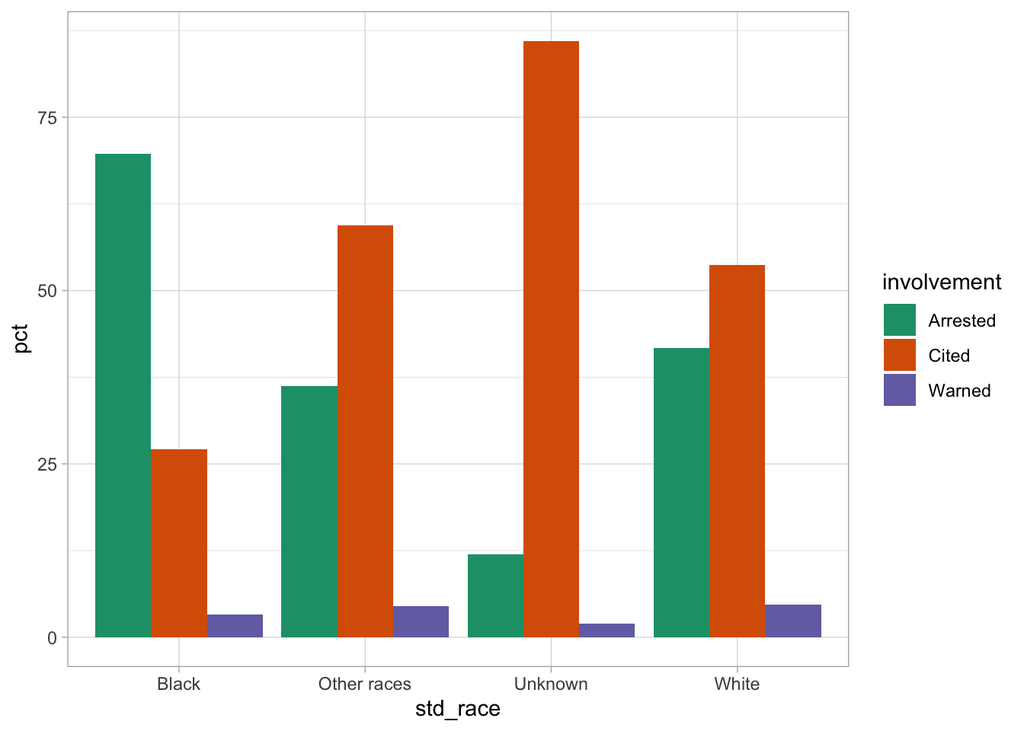

```r
ggplot ( data= std_race ,
         aes (x=std_race,  y= pct, fill=involvement)
        ) +
        geom_bar( stat= "identity" , position=position_dodge() ) +
        theme_light() +
        scale_fill_brewer(palette="Dark2") +
        theme (legend.position = "right")
```